# TP3: survie et estimation non-paramétrique

**Important:** Ceci est un document R notebook. En cliquant sur knit vous aurez le choix entre un document html, pdf ou word. Le TP doit être rendu sous la forme d’un fichier NOM_prenom_RegLog.html. Il est à remettre dans moodle. CTRL+Alt+i permet d’ouvrir une cellule de code compilable.

# 1 Fonctions utiles

Le package `asaur` contient une dizaine de datasets de survie. Nous allons notamment travailler sur les datasets `gastricXelox` et `pharmacoSmoking` dont vous pouvez avoir un aperçu grâce à la fonction `glimpse` (package `tidyverse`)

```r
rm(list=ls())
library(survival)
library(asaur)
library(tidyverse)
library(ggfortify)
glimpse(pharmacoSmoking)
```

```
## Rows: 125
## Columns: 14
## $ id             <int> 21, 113, 39, 80, 87, 29, 16, 35, 54, 70, 84, 85, 25, 47…
## $ ttr            <int> 182, 14, 5, 16, 0, 182, 14, 77, 2, 0, 12, 182, 21, 3, 1…
## $ relapse        <int> 0, 1, 1, 1, 1, 0, 1, 1, 1, 1, 1, 0, 1, 1, 1, 1, 1, 0, 1…
## $ grp            <fct> patchOnly, patchOnly, combination, combination, combina…
## $ age            <int> 36, 41, 25, 54, 45, 43, 66, 78, 40, 38, 64, 51, 37, 65,…
## $ gender         <fct> Male, Male, Female, Male, Male, Male, Male, Female, Fem…
## $ race           <fct> white, white, white, white, white, hispanic, black, bla…
## $ employment     <fct> ft, other, other, ft, other, ft, pt, other, ft, ft, oth…
## $ yearsSmoking   <int> 26, 27, 12, 39, 30, 30, 54, 56, 25, 23, 30, 35, 23, 50,…
## $ levelSmoking   <fct> heavy, heavy, heavy, heavy, heavy, heavy, heavy, light,…
## $ ageGroup2      <fct> 21-49, 21-49, 21-49, 50+, 21-49, 21-49, 50+, 50+, 21-49…
## $ ageGroup4      <fct> 35-49, 35-49, 21-34, 50-64, 35-49, 35-49, 65+, 65+, 35-…
## $ priorAttempts  <int> 0, 3, 3, 0, 0, 2, 0, 10, 4, 10, 12, 1, 5, 6, 5, 2, 1, 1…
## $ longestNoSmoke <int> 0, 90, 21, 0, 0, 1825, 0, 15, 7, 90, 365, 7, 1095, 180,…
```

```r
summary(gastricXelox)
```

```
##    timeWeeks          delta
##  Min.   :  4.00   Min.   :0.0000
##  1st Qu.: 18.50   1st Qu.:0.0000
##  Median : 43.00   Median :1.0000
##  Mean   : 59.71   Mean   :0.6667
##  3rd Qu.: 64.50   3rd Qu.:1.0000
##  Max.   :253.00   Max.   :1.0000
```

```r
head(gastricXelox)
```

```
##   timeWeeks delta
## 1         4     1
## 2         8     1
## 3         8     1
## 4         8     1
## 5         9     1
## 6        11     1
```

```r
summary(pharmacoSmoking)
```

```
##        id              ttr            relapse               grp
##  Min.   :  1.00   Min.   :  0.00   Min.   :0.000   combination:61
##  1st Qu.: 33.00   1st Qu.:  8.00   1st Qu.:0.000   patchOnly  :64
##  Median : 67.00   Median : 49.00   Median :1.000
##  Mean   : 66.15   Mean   : 77.44   Mean   :0.712
##  3rd Qu.: 99.00   3rd Qu.:182.00   3rd Qu.:1.000
##  Max.   :130.00   Max.   :182.00   Max.   :1.000
##       age           gender         race    employment  yearsSmoking
##  Min.   :22.00   Female:81   black   :38   ft   :72   Min.   : 9.00
##  1st Qu.:41.00   Male  :44   hispanic: 8   other:39   1st Qu.:22.00
##  Median :49.00               other   : 2   pt   :14   Median :30.00
##  Mean   :48.84               white   :77              Mean   :30.88
##  3rd Qu.:56.00                                        3rd Qu.:39.00
##  Max.   :86.00                                        Max.   :56.00
##  levelSmoking ageGroup2  ageGroup4  priorAttempts     longestNoSmoke
##  heavy:89     21-49:66   21-34:16   Min.   :   0.00   Min.   :   0.0
##  light:36     50+  :59   35-49:50   1st Qu.:   1.00   1st Qu.:   7.0
##                          50-64:48   Median :   2.00   Median :  90.0
##                          65+  :11   Mean   :  12.68   Mean   : 539.7
##                                     3rd Qu.:   5.00   3rd Qu.: 365.0
##                                     Max.   :1000.00   Max.   :6205.0
```

```r
head(pharmacoSmoking)
```

```
##    id ttr relapse         grp age gender     race employment yearsSmoking
## 1  21 182       0   patchOnly  36   Male    white         ft           26
## 2 113  14       1   patchOnly  41   Male    white      other           27
## 3  39   5       1 combination  25 Female    white      other           12
## 4  80  16       1 combination  54   Male    white         ft           39
## 5  87   0       1 combination  45   Male    white      other           30
## 6  29 182       0 combination  43   Male hispanic         ft           30
##   levelSmoking ageGroup2 ageGroup4 priorAttempts longestNoSmoke
## 1        heavy     21-49     35-49             0              0
## 2        heavy     21-49     35-49             3             90
## 3        heavy     21-49     21-34             3             21
## 4        heavy       50+     50-64             0              0
## 5        heavy     21-49     35-49             0              0
## 6        heavy     21-49     35-49             2           1825
```

1. Créer une fonction permettant de calculer l’estimateur de Kaplan-Meier pour la fonction de survie. Elle devra pouvoir fonctionner avec les datasets `pharmacoSmoking` et `gastricXelox`. On pourra utiliser les fonctions (order et unique). Effectuer une représantation graphique de vos résultats.

### 1.0.1 Fonctions & étude de pharmacoSmoking

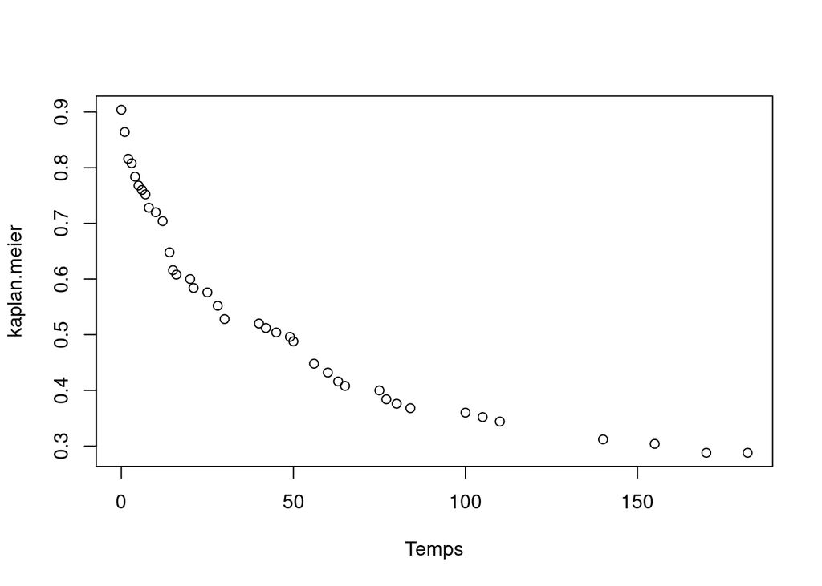

```r
kaplan.meier = function(t, X, delta){
  n = length(X)
  TT = unique(X)
  TT = TT[order(TT)]
  TT = TT[which(TT <= t)]
  S = 1
  Y = n
  for (ti in TT){
    di = length(X[which(X == ti & delta == 1)])
    S = S * (1 -  di / Y)
    Y = Y - length(X[which(X == ti)])
  }
  return(S)
}

data = pharmacoSmoking
delta = data$relapse
X = data$ttr

func.rep = function(f, X, delta, plot_bool = TRUE, legendd = FALSE){
  TT = unique(X)
  TT = TT[order(TT)]
  S = rep(0, length(TT))
  for (i in 1:length(TT)){
    S[i] = f(TT[i], X, delta)
  }
  if (plot_bool){
  plot(TT, S, xlab = 'Temps', ylab = as.character(substitute(f)))
  if (legendd){
  legend(100, .9, legendd, lwd=2, bty='n')
  }
  }
  return(S)
}

S = func.rep(kaplan.meier, X, delta)
```

2. Créer une fonction permettant de calculer l’estimateur de Greenwood de la variance. Effectuer une représantation graphique de vos résultats.

   ```r
   greenwood = function(t, X, delta){
     S = kaplan.meier(t, X, delta)
     n = length(X)
     TT = unique(X)
     TT = TT[order(TT)]
     TT = TT[which(TT <= t)]
     Y = n
     count = 0
     for (ti in TT){
       di = length(X[which(X == ti & delta == 1)])
       count = count + di / (Y * (Y - di))
       Y = Y - length(X[which(X == ti)])
     }
     return(S * S * count)
   }

   V = func.rep(greenwood, X, delta)
   ```

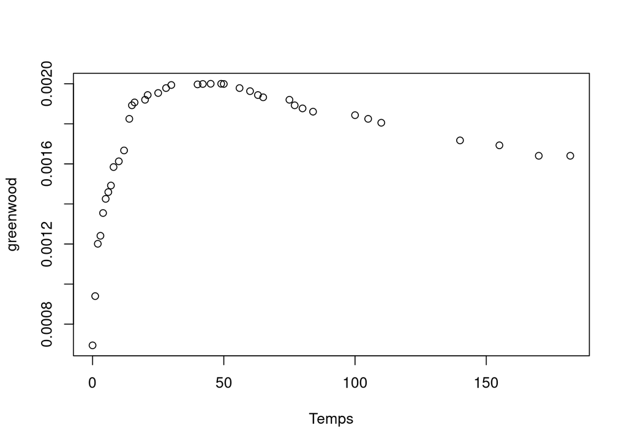

3. Créer une fonction permettant de calculer les estimateurs de Nelson-Aalen et de Breslow du risque cumulé. Effectuer une représantation graphique de vos résultats.

   ```r
   nelson.aalen = function(t, X, delta){
     n = length(X)
     TT = unique(X)
     TT = TT[order(TT)]
     TT = TT[which(TT <= t)]
     Y = n
     count = 0
     for (ti in TT){
       di = length(X[which(X == ti & delta == 1)])
       count =  count + di / Y
       Y = Y - length(X[which(X == ti)])
     }
     return(count)
   }

   breslow = function(t, X, delta){
     n = length(X)
     TT = unique(X)
     TT = TT[order(TT)]
     TT = TT[which(TT <= t)]
     Y = n
     count = 0
     for (ti in TT){
       di = length(X[which(X == ti & delta == 1)])
       count = count + log(1 - di / Y)
       Y = Y - length(X[which(X == ti)])
     }
     return(- count)
   }



   NAA = func.rep(nelson.aalen, X, delta)
   ```

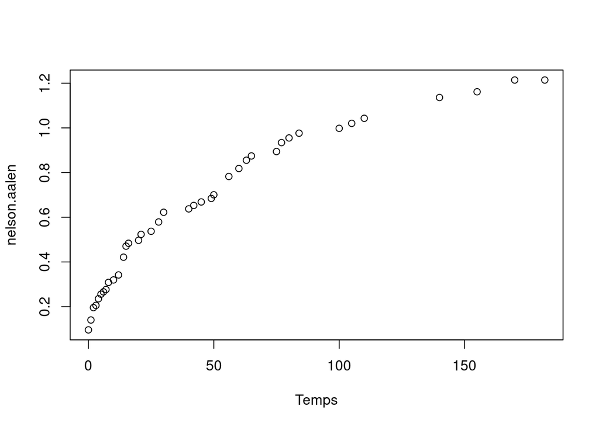

   ```r
   B = func.rep(breslow, X, delta)
   ```

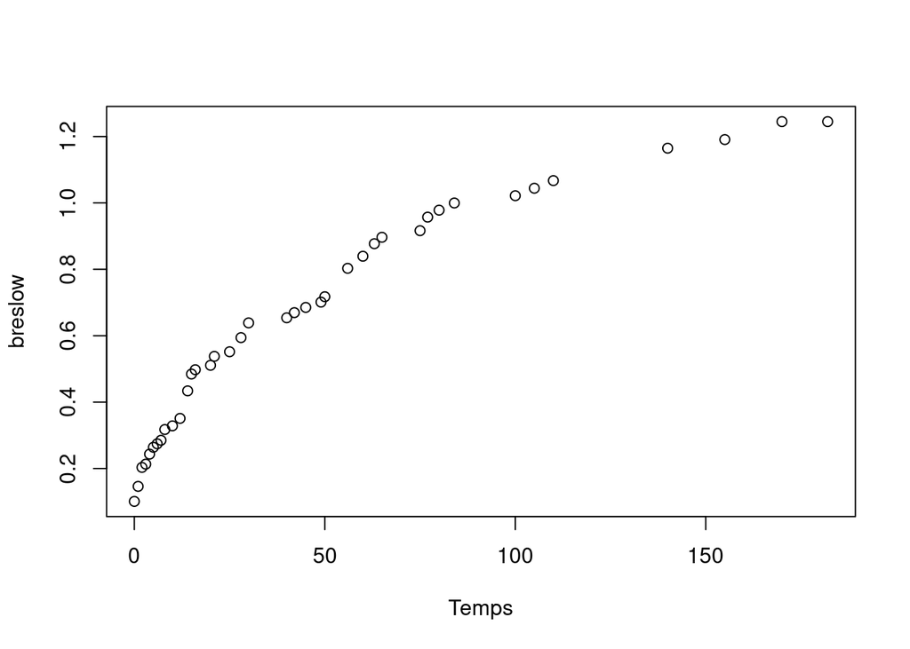

4. Créer une fonction renvoyant l’estimateur de la fonction de survie par la méthode actuarielle. Les pas de temps seront identiques et la fonction prendra en paramètre le nombre de coupures $K.$ On comparera les résultats obtenus avec les résultats de l’estimateur de Kaplan-Meier pour différentes valeurs de $K.$

   ```r
   actuarielle = function(t, X, delta){
     n = length(X)
     TT = unique(X)
     TT = TT[order(TT)]
     TT = TT[which(TT <= t)]
     S = 1
     Y = n
     for (ti in TT){
       di = length(X[which(X == ti & delta == 1)])
       dc = length(X[which(X == ti & delta == 0)])
       S = S * (1 -  di / (Y - dc/2))
       Y = Y - length(X[which(X == ti)])
     }
     return(S)
   }

   AC = func.rep(actuarielle, X, delta)
   ```

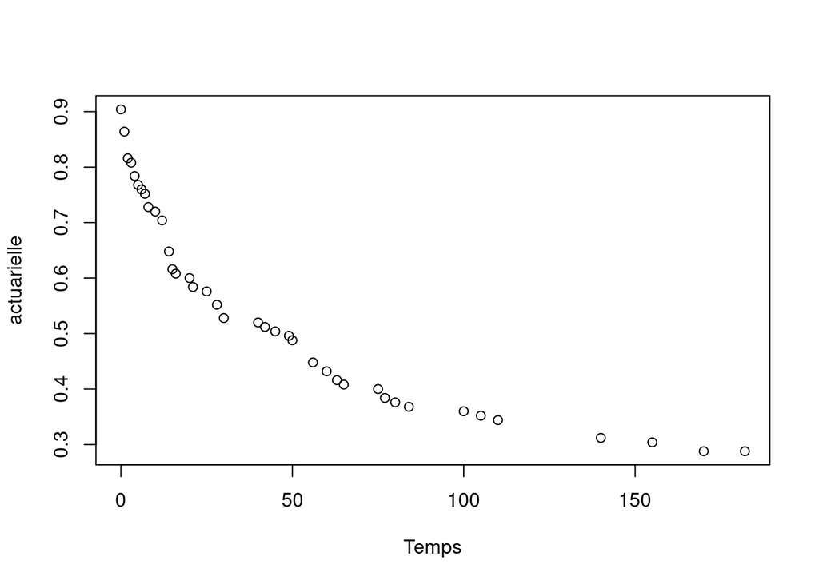

### Application à gastrox

   ```r
   data=gastricXelox
   delta = data$delta
   X = data$timeWeeks
   ```

   ```r
   func = c(kaplan.meier, greenwood, nelson.aalen, breslow, actuarielle)
   for (f in func){
     func.rep(f, X, delta)
   }
   ```

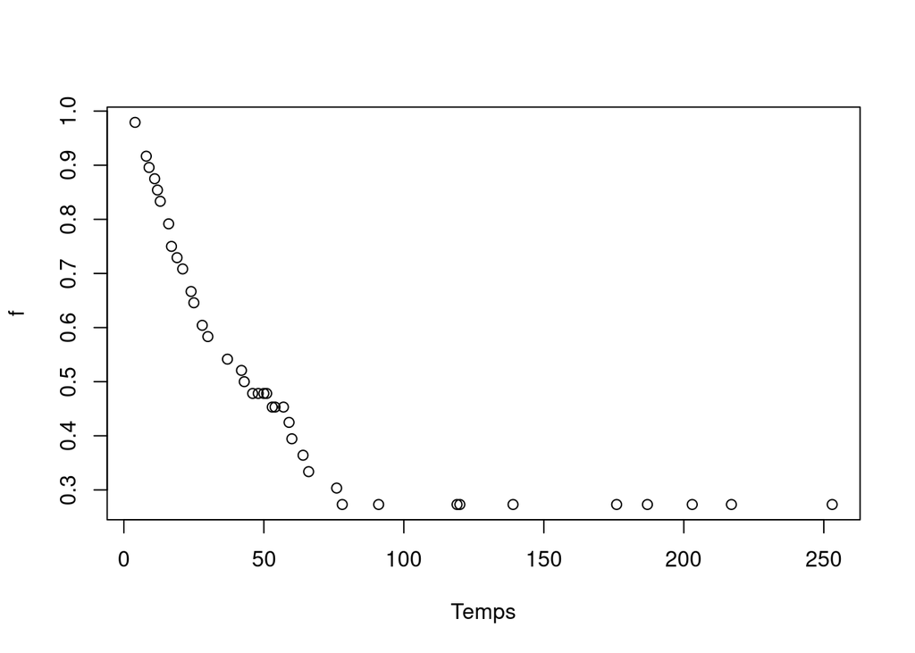

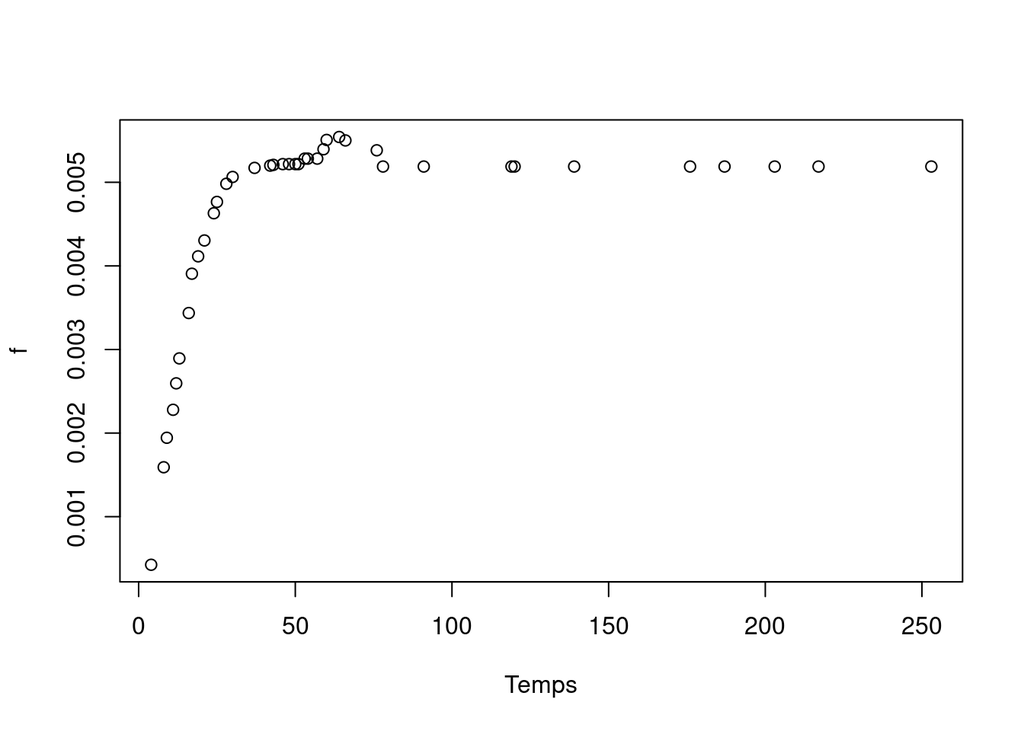

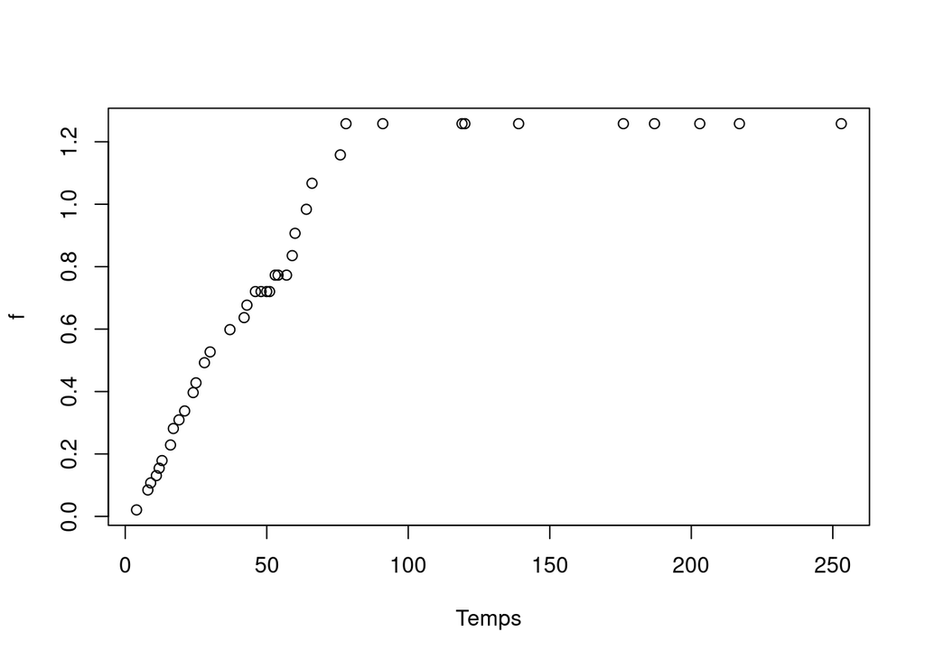

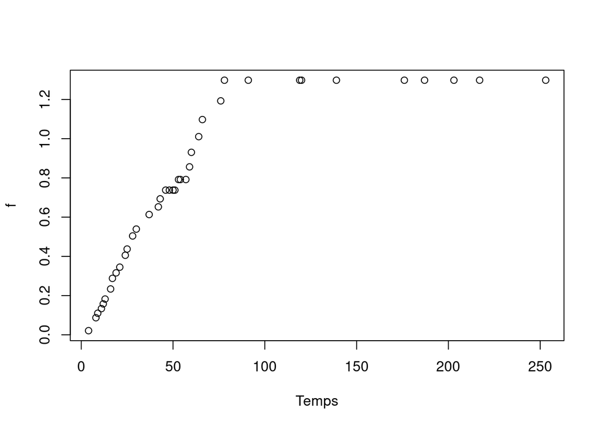

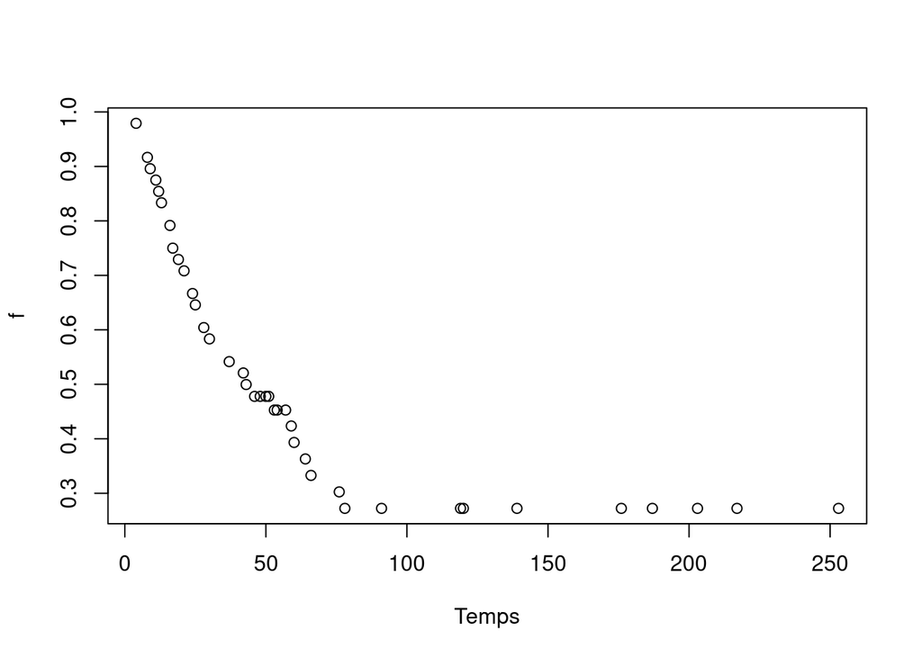

   ```r
   # élégant mais problème d'affichage du y_label
   ```

5. Comparrer les résultats obtenus à la question 1 et 2 avec ceux de la fonction `survfit` (package `survival`).

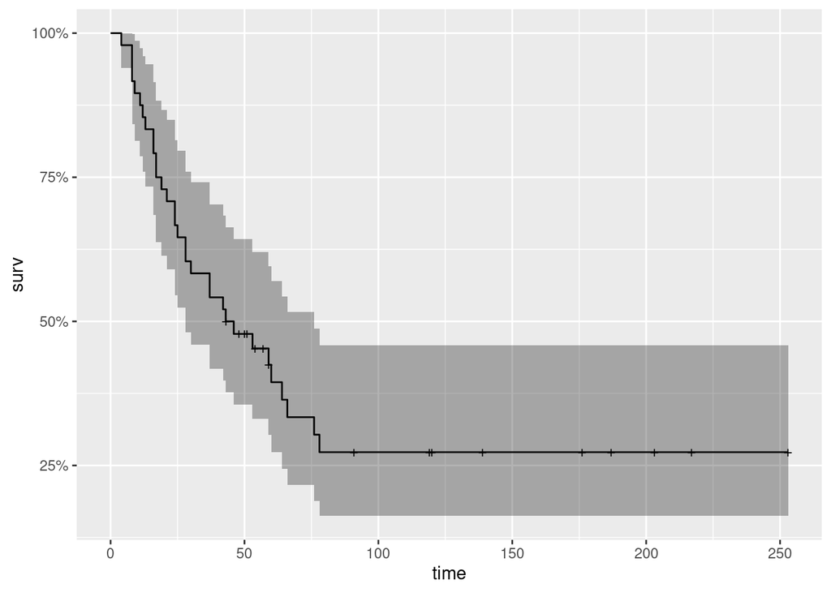

```r
km = survfit(Surv(timeWeeks, delta) ~ 1, data = gastricXelox)
autoplot( km )
```

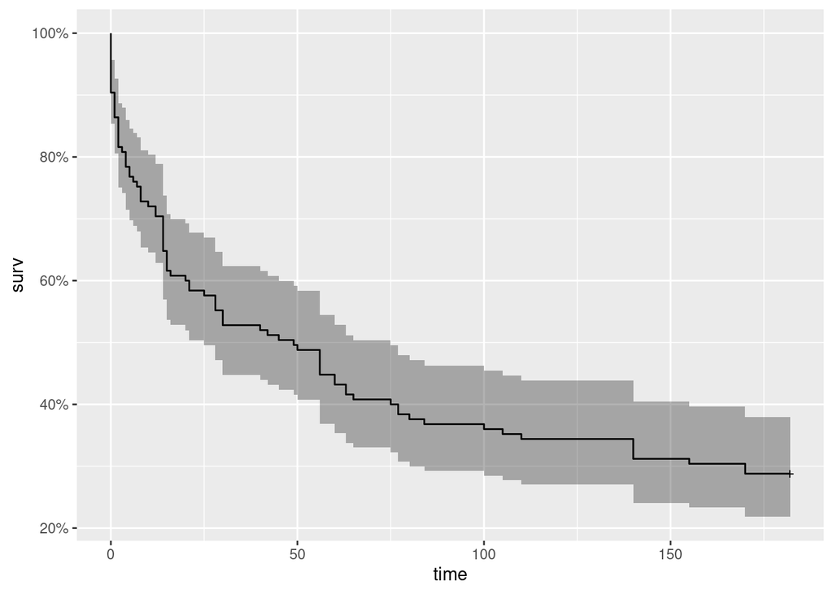

```r
km2 = survfit(Surv(ttr, relapse) ~ 1, data = pharmacoSmoking)
autoplot( km2 )
```

# 2 Analyse du jeu de données `pharmacosmoking`

Etudier l’impact des covariables `levelSmoking`, `grp`, `ageGroup2`, `ageGroup4` et `employment`. L’objet de cette question est l’interprétation et la présentation scientifique des résulats que vous avez obtenus, soit par vos fonctions soit par la fonction `survfit` ( voir fonction `summary` et `attributes` appliquées à l’objet de classe `survfit`). On pensera notamment à utiliser des tests et des intervalles de confiance appliqués à quelques instants choisis de l’espace de temps.

## 2.1 Concentration de tous nos graphes

```r
data = pharmacoSmoking
delta = data$relapse
X = data$ttr

func = c(kaplan.meier, greenwood, nelson.aalen, breslow, actuarielle)
for (f in func){
  func.rep(f, X, delta)
}
```

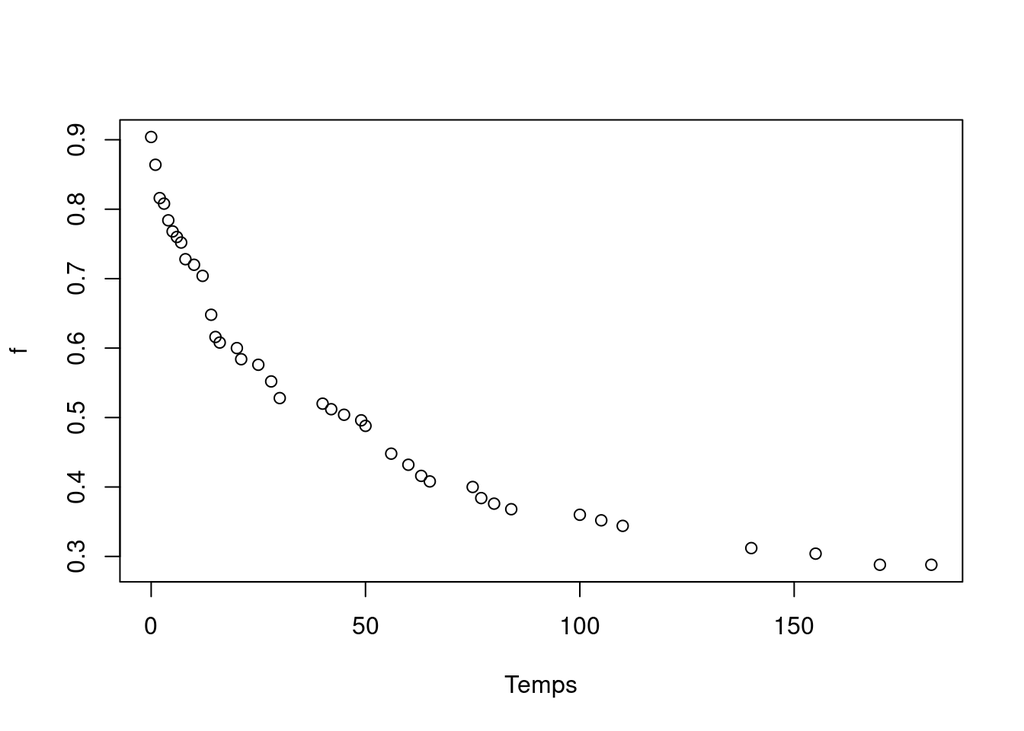

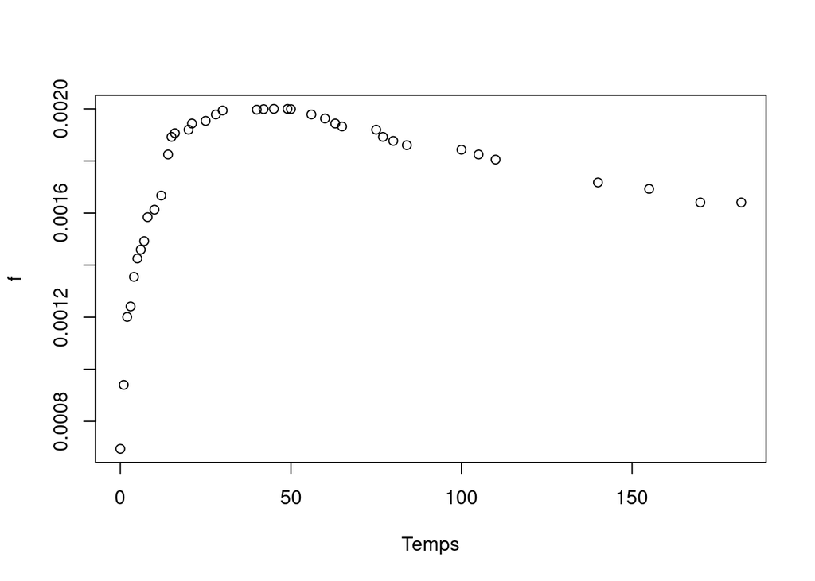

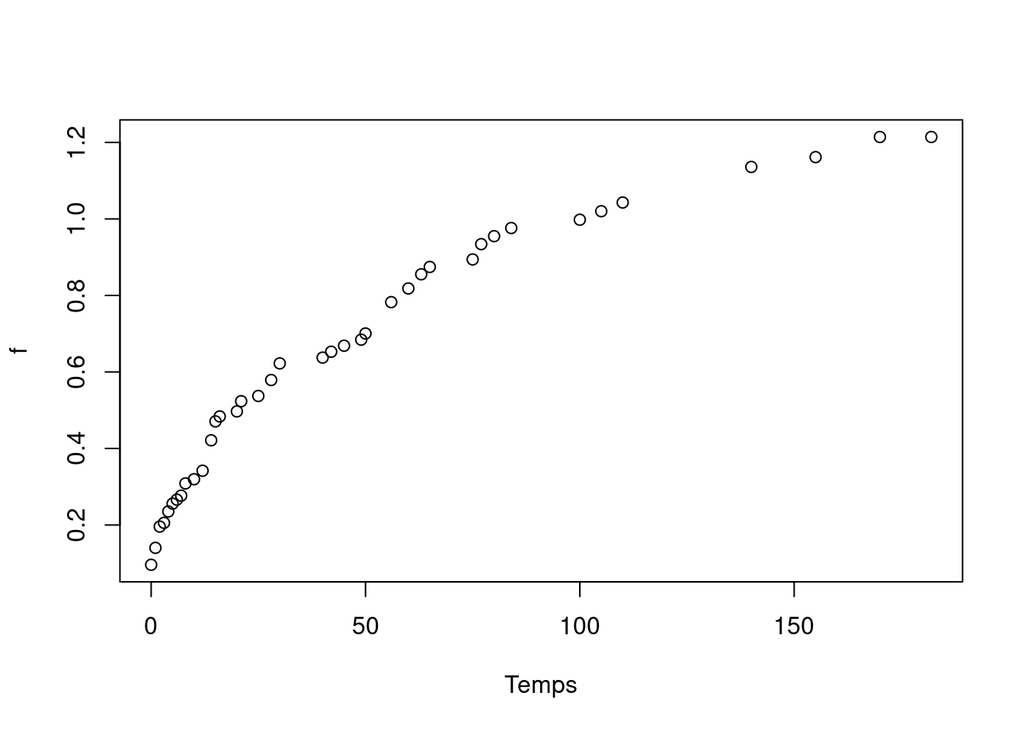

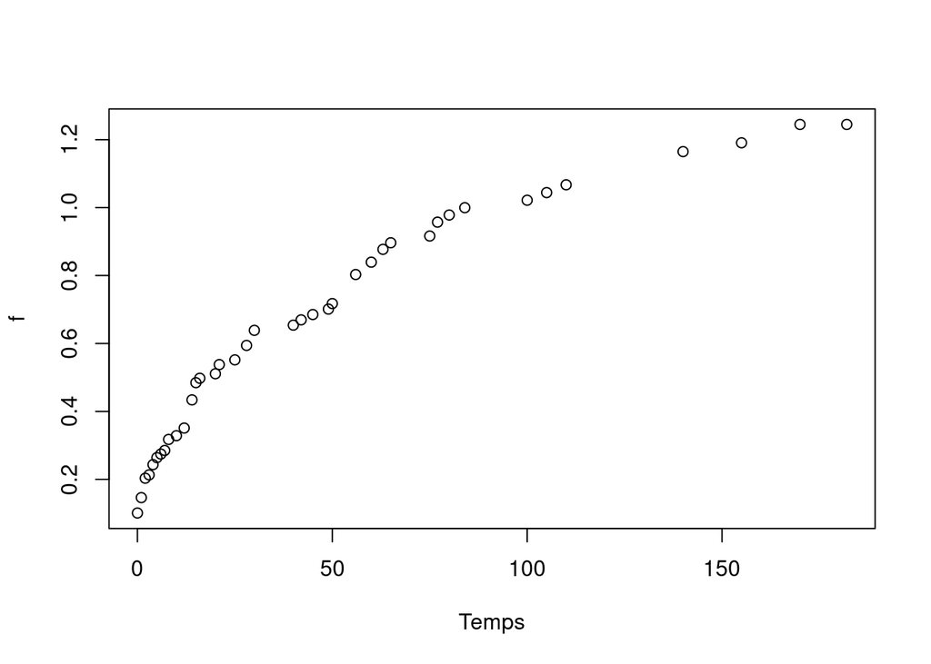

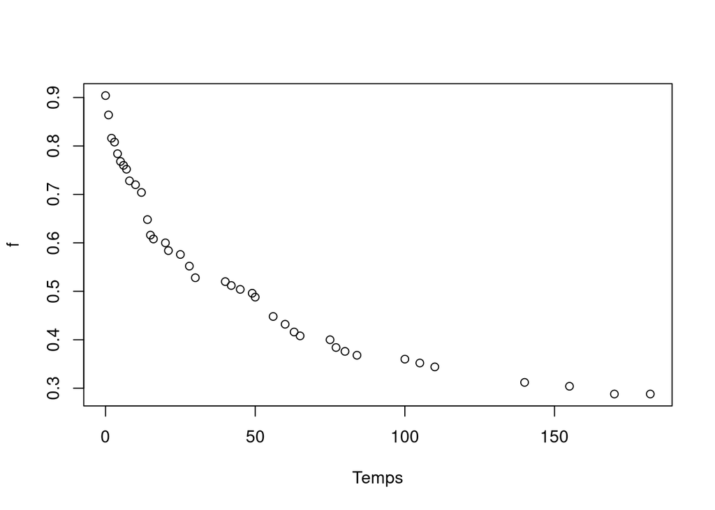

```r
# élégant mais problème d'affichage du y_label
```

## 2.2 Analyse de survfit

```r
summary(km2)
```

```
## Call: survfit(formula = Surv(ttr, relapse) ~ 1, data = pharmacoSmoking)
##
##  time n.risk n.event survival std.err lower 95% CI upper 95% CI
##     0    125      12    0.904  0.0263        0.854        0.957
##     1    113       5    0.864  0.0307        0.806        0.926
##     2    108       6    0.816  0.0347        0.751        0.887
##     3    102       1    0.808  0.0352        0.742        0.880
##     4    101       3    0.784  0.0368        0.715        0.860
##     5     98       2    0.768  0.0378        0.697        0.846
##     6     96       1    0.760  0.0382        0.689        0.839
##     7     95       1    0.752  0.0386        0.680        0.832
##     8     94       3    0.728  0.0398        0.654        0.810
##    10     91       1    0.720  0.0402        0.645        0.803
##    12     90       2    0.704  0.0408        0.628        0.789
##    14     88       7    0.648  0.0427        0.569        0.737
```

[output cut: 26 more lines]

#### 2.2.0.1 Explication des colonnes du tableau obtenu par summary:

time contient les instants où un évènement s’est produit, mais ne tient pas compte des instants où seule une censure s’est produite (exemple : pour gastrox, il y a une censure à t=57 or t=57 n’apparait pas dans le summary(km))

n.risk : ce qu’on appelle Yi

n.event : ce qu’on appelle di

survival : estimation par km de la fonction de survie

std : estimation par greenwood de l’écart type

95% CI bounds : obtenues par le théorème de normalité asymptotique de KM ?

#### 2.2.0.2 Interprétation du tableau

En utilisant les bornes à 95%, 1 personne sur 2 recommençera à fumer dans les 65 jours qui suivent l’arrêt.

La probabilité de réussir à arrêter de fumer est de 0.288 +- 0.1 ie 25% des gens réussissent à arrêter de fumer.

# 3 Calcul de la fonction de survie pour chaque groupe

Plus fin, on sépare le jeu de données en k jeux de données selon la valeur d’une covariable possédant k classes. On calcule la fonction de survie pour chaque groupe, et on regarde si elle change.

~ on étudie dans un premier temps l’influence de grp

```r
data = pharmacoSmoking
delta = data$relapse
X = data$ttr

covariable.influence = function(covariable, X, delta){
  labels = unique(covariable)
  for (i in 1:length(labels)){
    Xi = X[which(covariable == labels[i])]
    deltai = delta[which(covariable == labels[i])]
    func.rep(kaplan.meier, Xi, deltai, legendd = labels[i])
  }
}
```

## 3.1 grp

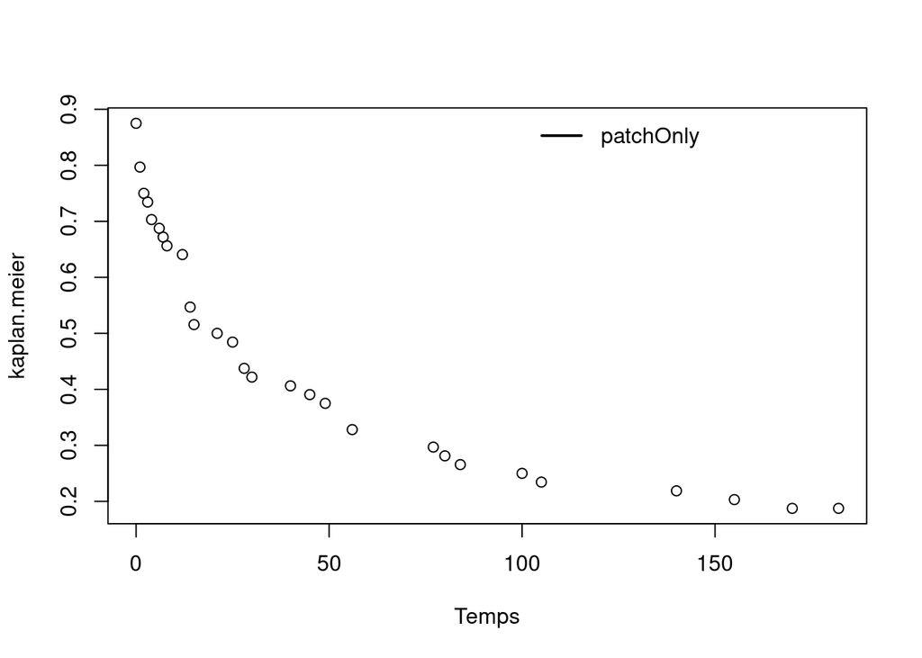

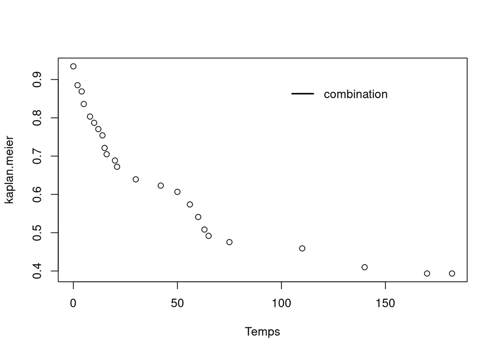

```r
covariable = data$grp
covariable.influence(covariable, X, delta)
```

## 3.2 levelSmoking

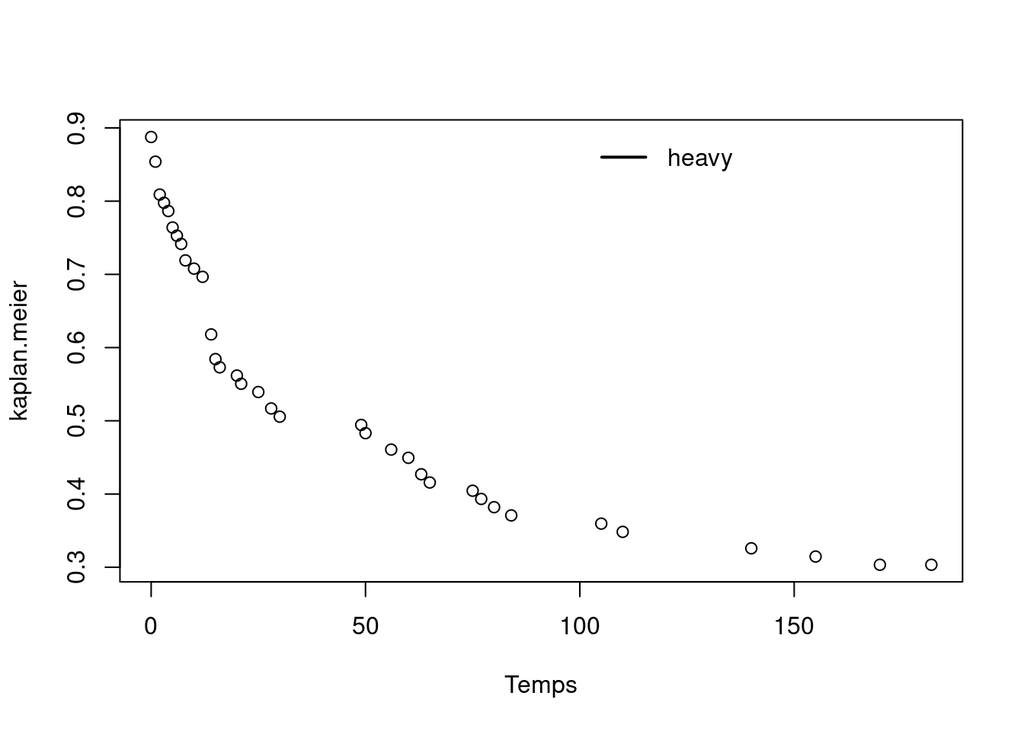

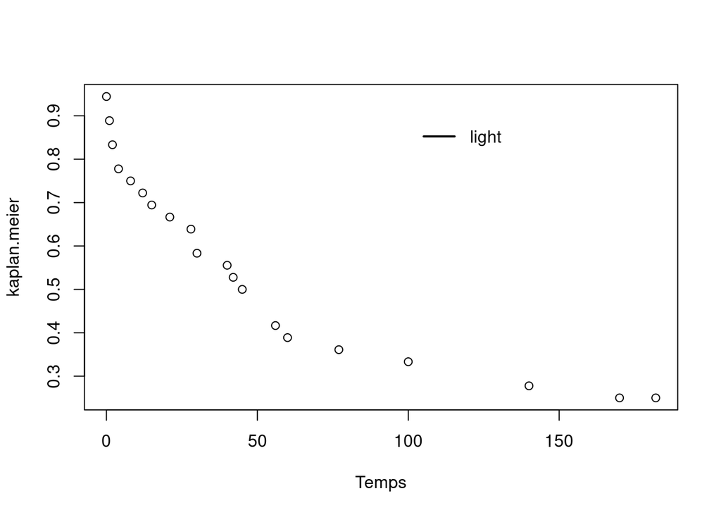

```r
covariable = data$levelSmoking
covariable.influence(covariable, X, delta)
```

## 3.3 ageGroup2

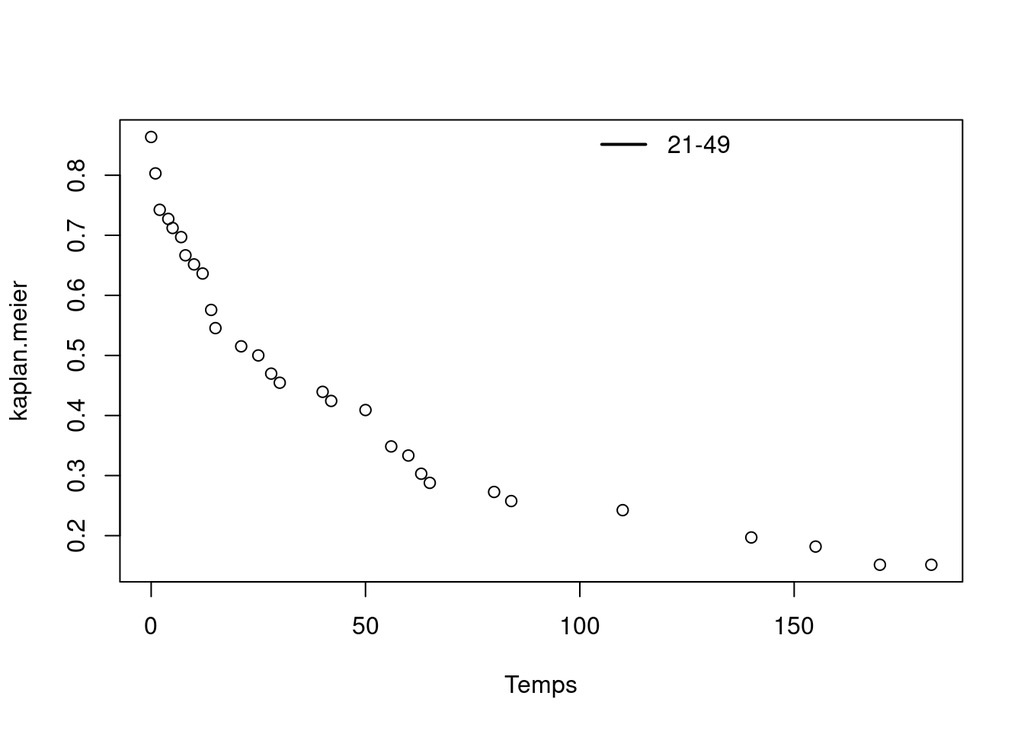

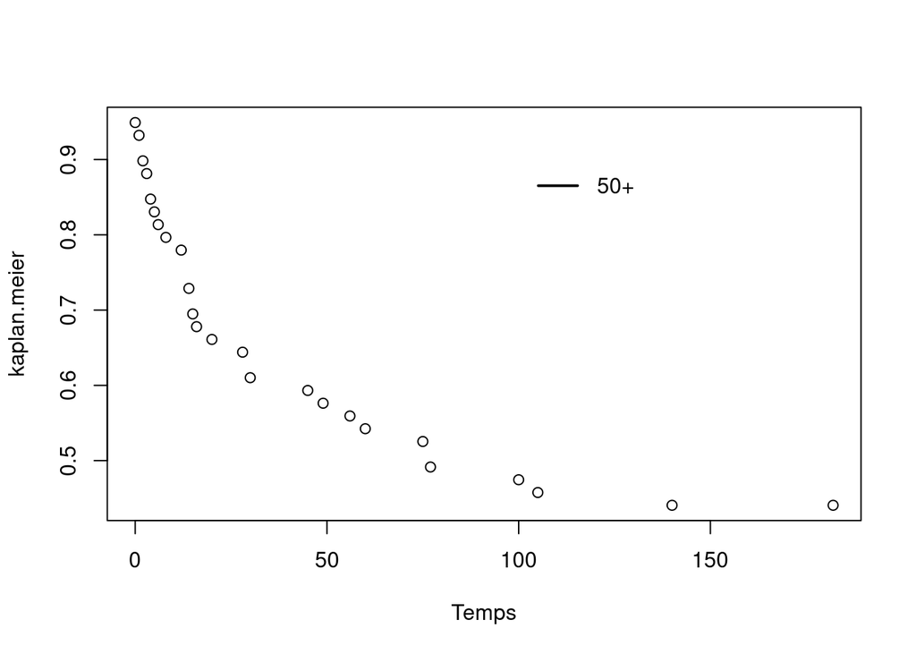

```r
covariable = data$ageGroup2
covariable.influence(covariable, X, delta)
```

Les 21-49 ont peu de résistance (S= 0.5 pour t=25), tandis que la fonction de survie des fumeurs de +50 ans est toujours supérieure à 0.5 pour t = 75. Une personne agée a plus de raisons d’arrêter de fumer qu’un jeune, et se trouve moins dans des environnements à risques ?

## 3.4 ageGroup4

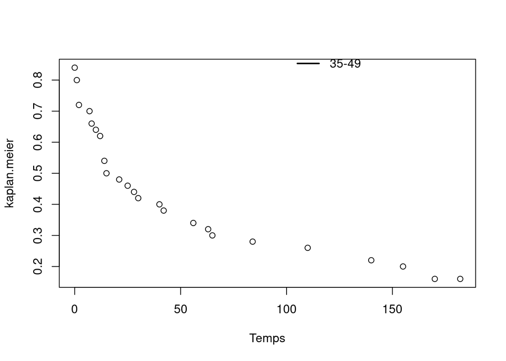

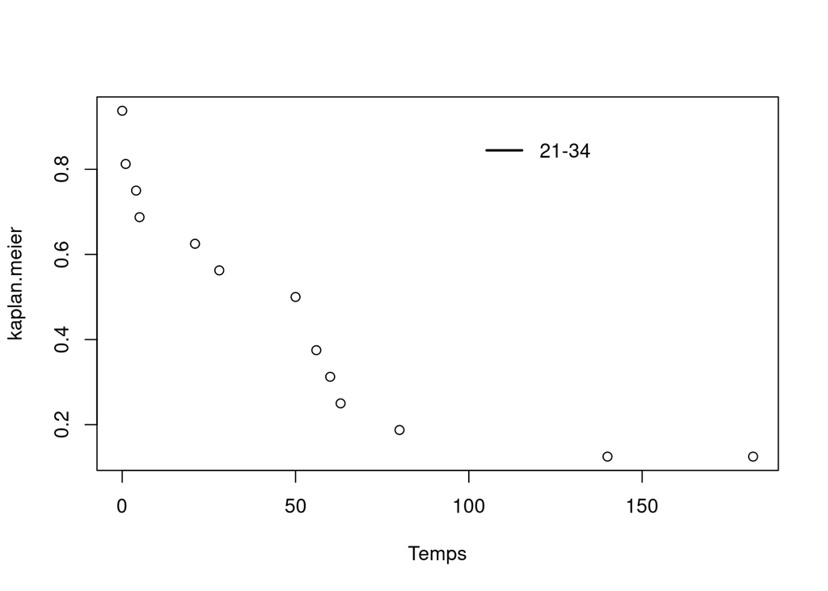

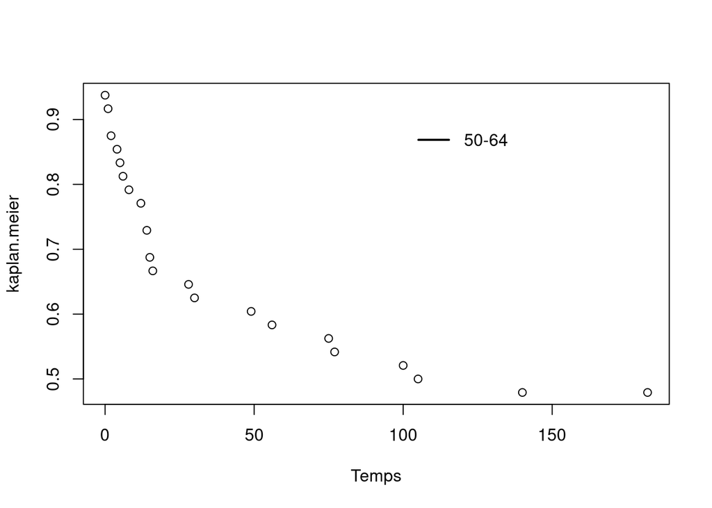

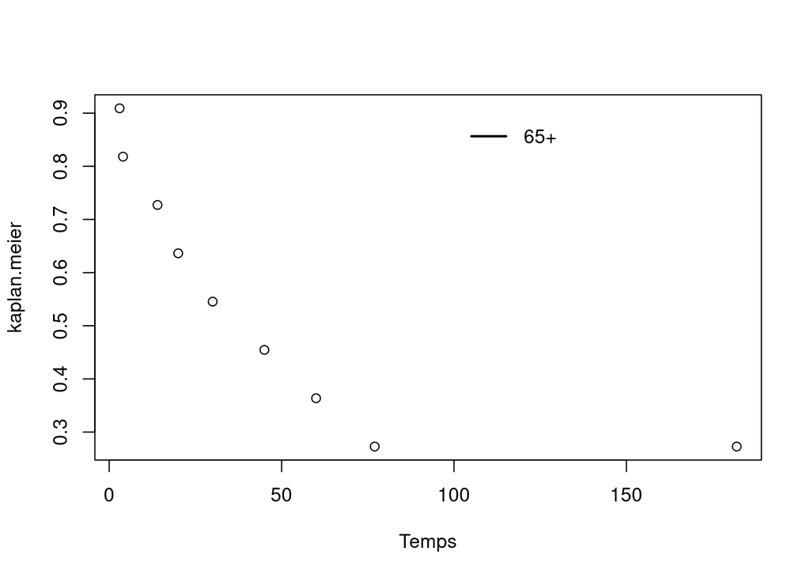

```r
covariable = data$ageGroup4
covariable.influence(covariable, X, delta)
```

Les personnes de +65 ans reprennent plus tôt que les 50-65. Pour continuer à fumer à 65 ans, lls doivent être habitués et cela doit leur sembler naturel. De plus, fumer à 65 ans signifie qu’ils n’ont jamais réussi à arrêter durant leur vie. Intuitivement, c’est donc naturel qu’ils échouent à arrêter à nouveau.

## 3.5 employment

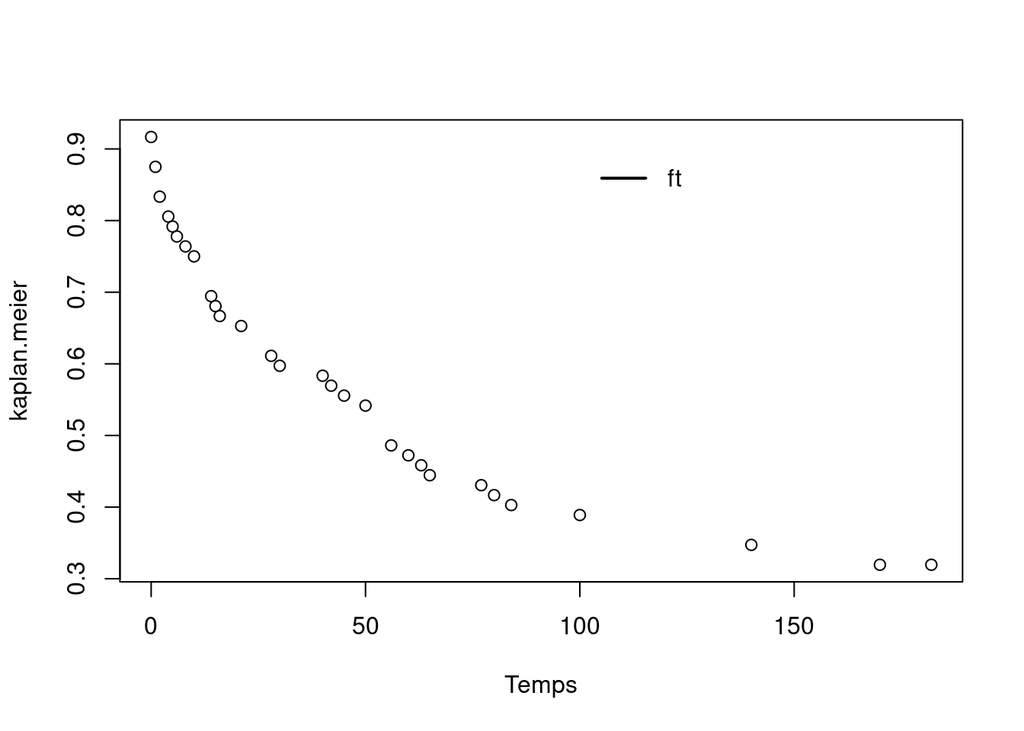

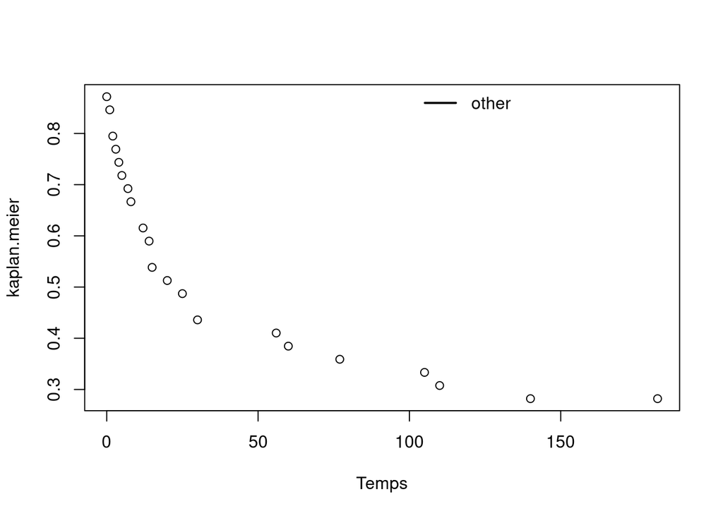

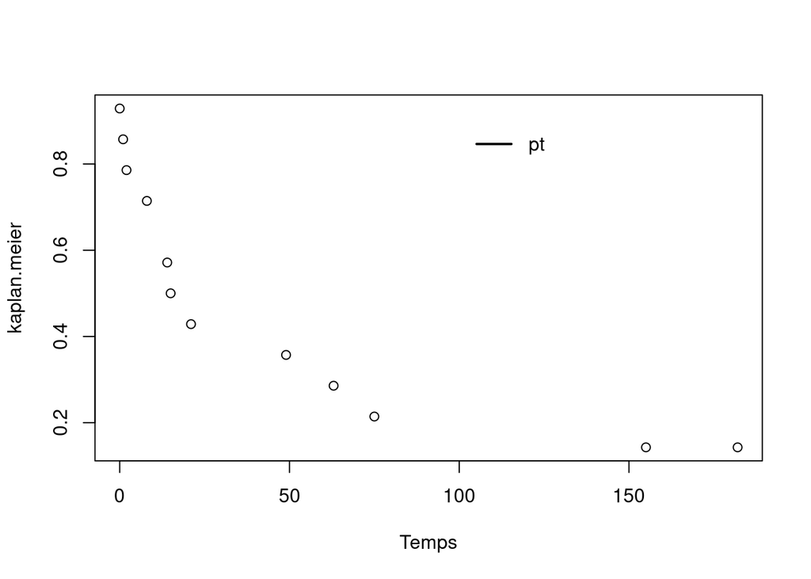

```r
covariable = data$employment
covariable.influence(covariable, X, delta)
```

Je ne sais pas ce que les classes signifient mais les pt sont plus susceptibles de reprendre, ensuite les other, et ensuite les ft.

## 3.6 Réflexions sur la pertinence de cette méthode

Les classes ne sont pas équilibrées. Or, la fonction de survie dépend grandement du n, le nombre d’individus de l’échantillon. Ainsi, y a t-il un sens à comparer des échantillons ayant des n différents ?

# 4 Autres idées non implémentées

## 4.1 Calcul manuel de l’intervalle de confiance de S(t) à partir du théorème de normalité asymptotique de KM

C’est analogue au TCL

## 4.2 Régression logistique

Les données censurées correspondent aux individus ayant survécu jusqu’à la fin de l’étude.

On peut donc fitter une régression logistique, en utilisant delta comme variable binaire de succès. L’étude des p_valeurs du test de Wald nous indiquera quelles variables sont corrélées avec le fait de survivre ou non.

## 4.3 Tables d’adjacences des covariables et de relapse

Les covariables sont toutes catégorielles.

On peut donc afficher les proportions de survie finales selon l’appartenance à chaque catégorie, si les résultats diffèrent, cela signifie que cette covariable est importante.